# Session 3 Code (day 2)

# Box-and-whisker plots

Box-and-whisker plots are great for showing basic statistics related to central tendency and spread for data. We could, naturally, present some of these statistics as a scatterplot.

Start by selecting 6 typical years. **Warning**: the code below overwrites the data set!

```r
df_qog_21 <- df_qog_21 %>%
  filter(year %in% c(1965, 1975, 1985, 1995, 2005, 2015)) %>%
  mutate(year = as.factor(year))
```

```r
df_qog_summ <- df_qog_21 %>%
    group_by(year) %>%
    summarise(gini = mean(gini, na.rm = TRUE))
```

We start with something we already know: a scatterplot presenting means of Gini in each time period.

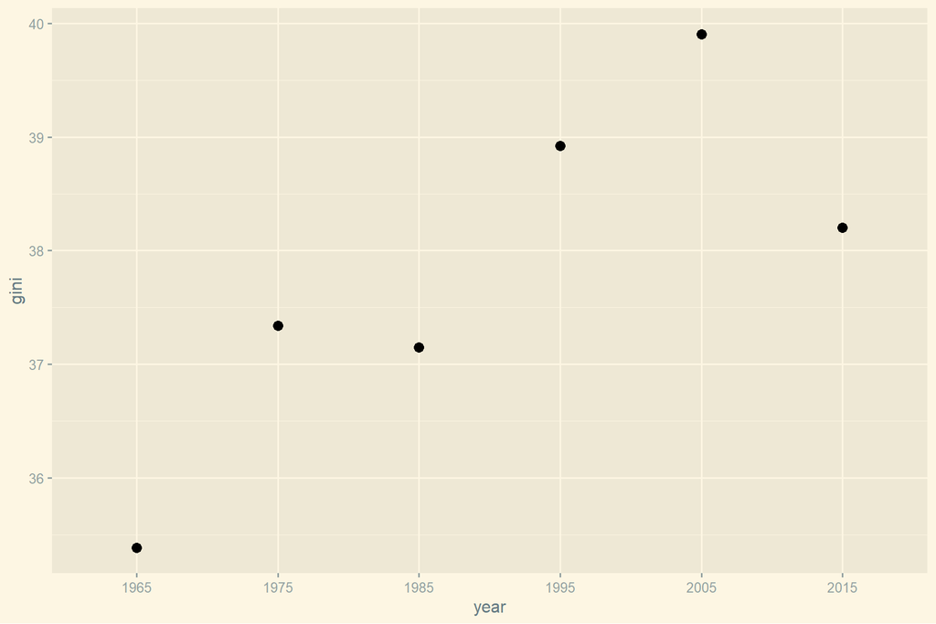

```r
ggplot(data = df_qog_summ,
       mapping = aes(x = year,
                     y = gini)) +
  geom_point(size=3) +
  theme_solarized_2()
```

This strategy can only get you so far, though. It’s certainly helpful in conveying that since 1965 income inequality has generally been on an upward trend until about the mid-2000s. However, it doesn’t say much about the spread in inequality over the same period, or whether this change in the mean has simply taken place because of a few outliers in the data. A box-and-whisker plot can help depict a wider variety of statistics at the same time.

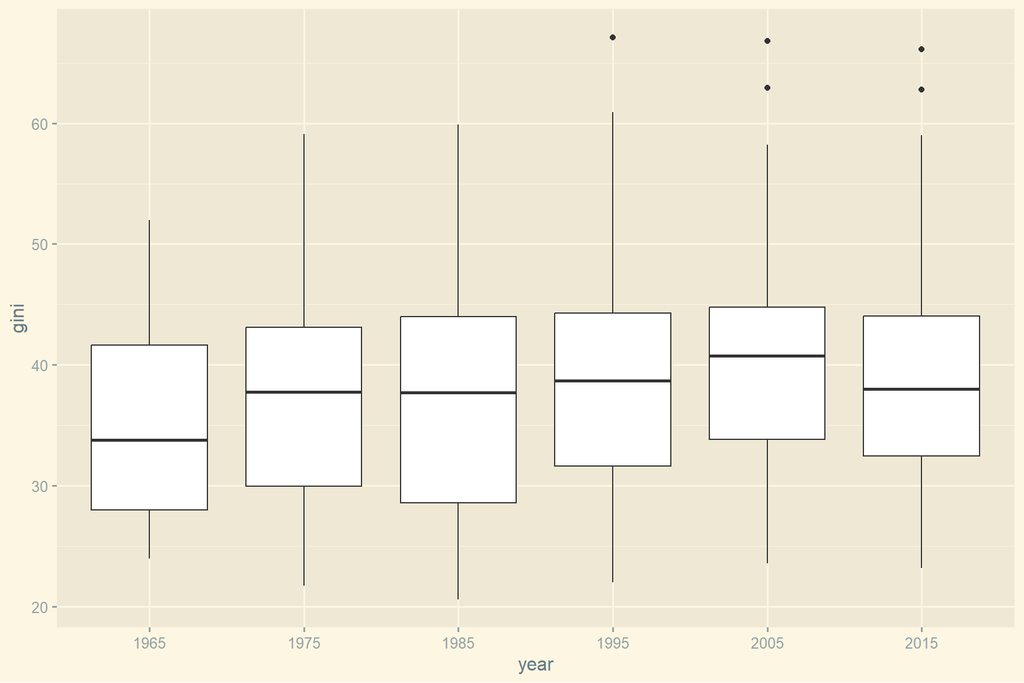

```r
ggplot(data = df_qog_21,
       mapping = aes(x = year,
                     y = gini,
                     group = year)) + # Asking for separate boxes per year
  geom_boxplot() +
  theme_solarized_2()
```

Elements of the plot:

- The middle bar shows you the median
- The bottom and top edges of the boxplot show you the lower quartile and the upper quartile. That means 50% of the cases lie inside the box.
- The bottom and top whiskers show where the bottom 25% of cases and top 25% of cases are on the scale (it’s not fully 50%, as the boxplot will also show a few outliers, if any).

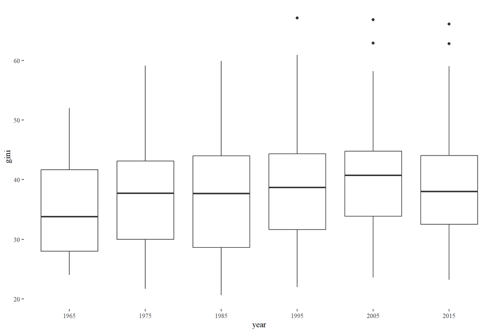

```r
ggplot(data = df_qog_21,
       mapping = aes(x = year,
                     y = gini,
                     group = year)) +
    geom_boxplot() +
    theme_tufte()
```

The `ggthemes` package actually has a `geom_` that produces a boxplot based on Tufte’s recommendations.

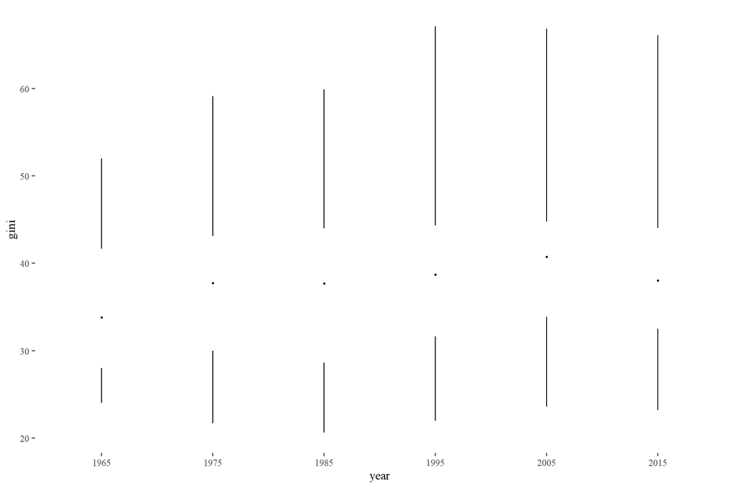

```r
df_qog_21 <- df_qog_21 %>%
    mutate(year = as.character(year))
ggplot(data = df_qog_21,
       mapping = aes(x = year,
                     y = gini,
                     group = year)) +
    geom_tufteboxplot() +
    theme_tufte()
```

# Saving plots

The easy function to save all your `ggplot2` plots is `ggsave()`. Let’s first generate the final plot, as we want to see it in the report, or in the publication. Normally, you don’t need to specify `as.numeric()`; I only do it here because we forced the variable to be `character` above (to solve an annoying error in the `geom_tufteboxplot()` function).

```r
p1 <- ggplot(data = df_qog_21,
             mapping = aes(x = as.numeric(year),
                           y = gini,
                           group = as.numeric(year))) +
    geom_boxplot(alpha = 0) + # Make box completely transparent
    theme_solarized_2() +
    labs(x = "Year",
         y = "Income inequality",
         title = "Economic inequality: trends over time")
```

Save as PDF, for space-saving, and maximum quality (though this can’t be added in Word). The defaults sizes are in inches (2.5 cm).

```r
ggsave(p1, file = "../04-graphs/03-01.pdf", height = 6, width = 8)
```

Save as PNG for decent quality and low space (easily added in Word):

```r
ggsave(p1, file = "../04-graphs/03-02.png", height = 6, width = 8,
       dpi = 200) # Quality of plot
```

Increase quality of plot, at the cost of size on hard drive.

```r
ggsave(p1, file = "../04-graphs/03-03.png", height = 6, width = 8,
       dpi = 400)
```

Other formats are available as well.

```r
ggsave(p1, file = "../04-graphs/03-04.jpeg", height = 6, width = 8,
       dpi = 400)
```

[^1]: Yesterday we were just displaying the resulting data, but now we want to store it in a separate object, so as to use it further in plotting.
[^2]: Though it might not look like it from the syntax, this function is running a regression in the background and displaying the line of best fit on the plot.
[^3]: Notice that I no longer specify `theme_bw()` anymore. This means that the plot will be reverted back to the original format - slightly dull, but definitely legible.